# Challenge2 Integration and Exploration

Xiang (Sean) Cheng (chengxiang.cn@gmail.com)

June 11, 2016

## Introduction

Given [3 datasets](https://github.com/seanxiangcheng/datachallenge/tree/master/data), explore and integrate them to gain insights.

The good thing is that the data points are clean and consistent within a dataset. The bad thing is that we have no idea what the data is about and how the data is collected. We can start with exploratory analysis.

## Data cleaning and information retrieval

1. load the data

```r
# data files paths
data_dir = "./data/"
f_activity = paste0(data_dir, "Activities.csv")
f_event1 = paste0(data_dir, "Events_1.csv")
f_event2 = paste0(data_dir, "Events_2.csv")

# load data
df.Act = read.csv(f_activity)
df.E1 = read.csv(f_event1)
df.E2 = read.csv(f_event2)
```

Notice that the information includes date, time, and activities. Most likely, the pattern may be hidden in the date and time. We need to convert the string-datetime into date and time data in R.

2. date and time information retrieval

```r
# process E1 data set
df.E1 = transform(df.E1, datetime.utc = ymd_hms(Timestamp))
df.E1 = transform(df.E1, weekday.utc = weekdays(datetime.utc), hour.uct=hour(datetime.utc))
df.E1 = subset(df.E1, select=-Timestamp)
df.E1 = transform(df.E1, datetime.edt = with_tz(datetime.utc, tzone="America/New_York"))
df.E1 = transform(df.E1, weekday.edt=weekdays(datetime.edt), hour.edt = hour(datetime.edt))

# process E2 data set
df.E2 = transform(df.E2, datetime.utc = ymd_hms(Timestamp))
df.E2 = transform(df.E2, weekday.utc = weekdays(datetime.utc), hour.uct=hour(datetime.utc))
df.E2 = subset(df.E2, select=-Timestamp)
df.E2 = transform(df.E2, datetime.edt = with_tz(datetime.utc, tzone="America/New_York"))
df.E2 = transform(df.E2, weekday.edt=weekdays(datetime.edt), hour.edt = hour(datetime.edt))

# process Activities data set
df.Act = transform(df.Act, Timestamp=paste(Date, Start))
df.Act = transform(df.Act, datetime.edt=mdy_hms(Timestamp, tz="America/New_York"))
df.Act = transform(df.Act, weekday.edt=weekdays(datetime.edt), hour.edt=hour(datetime.edt), gmt_ts=as.numeric(datetime.edt))
df.Act = subset(df.Act, select=-c(Date, Start, Time.Zone, Timestamp))

# generate relative gmt_ts for all data set
    ## this step is to avoid integer overflow and to make it easier to read
min_gmt_ts = min(min(df.Act$gmt_ts), min(df.Act$gmt_ts), min(df.Act$gmt_ts))
df.Act = transform(df.Act, relative_gmt_ts=gmt_ts-min_gmt_ts)
df.E1 = transform(df.E1, relative_gmt_ts=gmt_ts-min_gmt_ts)
df.E2 = transform(df.E2, relative_gmt_ts=gmt_ts-min_gmt_ts)

# only keep relative_gmt_ts and weekday inEDT for analysis
   ## p.s. weekdays are the day for all
df.Act = subset(df.Act, select=-gmt_ts)
df.E1 = subset(df.E1, select=-c(gmt_ts, weekday.utc))
df.E2 = subset(df.E2, select=-c(gmt_ts, weekday.utc))
```

3. new data tables examination

```r
kable(head(df.Act, 2), format = "markdown", align='l')
```

| ActivityCodes | datetime.edt | weekday.edt | hour.edt | relative_gmt_ts |
| --- | --- | --- | --- | --- |
| Activity_a | 2016-05-10 08:43:42 | Tuesday | 8 | 0 |
| Activity_b | 2016-05-10 08:56:01 | Tuesday | 8 | 739 |

```r
kable(head(df.E1, 2), format = "markdown", align='l')
```

| EventCodes | datetime.utc | hour.uct | datetime.edt | weekday.edt | hour.edt | relative_gmt_ts |
| --- | --- | --- | --- | --- | --- | --- |
| Event_A | 2016-05-10 11:07:29 | 11 | 2016-05-10 07:07:29 | Tuesday | 7 | -5773 |
| Event_A | 2016-05-10 11:07:29 | 11 | 2016-05-10 07:07:29 | Tuesday | 7 | -5773 |

```r
kable(head(df.E2, 2), format = "markdown", align='l')
```

| EventCodes | datetime.utc | hour.uct | datetime.edt | weekday.edt | hour.edt | relative_gmt_ts |
| --- | --- | --- | --- | --- | --- | --- |
| Event_C | 2016-05-10 17:22:07 | 17 | 2016-05-10 13:22:07 | Tuesday | 13 | 16705 |
| Event_C | 2016-05-10 17:22:07 | 17 | 2016-05-10 13:22:07 | Tuesday | 13 | 16705 |

## Exploratory analysis

1. Summary of columns of interest which are the columns with information of date, time, and activities/events.

```r
summary(df.Act)
```

```
##     ActivityCodes  datetime.edt                  weekday.edt
##  Activity_m:17    Min.   :2016-05-10 08:43:42   Tuesday:98
##  Activity_g:16    1st Qu.:2016-05-10 11:42:32
##  Activity_i:14    Median :2016-05-10 12:03:10
##  Activity_s: 8    Mean   :2016-05-10 13:00:54
##  Activity_n: 6    3rd Qu.:2016-05-10 15:28:40
##  Activity_o: 5    Max.   :2016-05-10 17:11:00
##  (Other)   :32
##     hour.edt     relative_gmt_ts
##  Min.   : 8.00   Min.   :    0
##  1st Qu.:11.00   1st Qu.:10731
##  Median :12.00   Median :11968
##  Mean   :12.52   Mean   :15432
##  3rd Qu.:15.25   3rd Qu.:24298
##  Max.   :17.00   Max.   :30438
##
```

```r
summary(df.E1[, c(-2, -3)])
```

```
##    EventCodes      datetime.edt                  weekday.edt
##  Event_A:    75   Min.   :2016-05-10 07:07:29   Tuesday:145574
##  Event_B:    22   1st Qu.:2016-05-10 09:22:39
##  Event_C:   136   Median :2016-05-10 09:53:34
##  Event_D:   480   Mean   :2016-05-10 10:00:55
##  Event_E:    15   3rd Qu.:2016-05-10 10:31:28
##  Event_F:   880   Max.   :2016-05-10 11:21:58
##  Event_G:143966
##     hour.edt      relative_gmt_ts
##  Min.   : 7.000   Min.   :-5773
##  1st Qu.: 9.000   1st Qu.: 2337
##  Median : 9.000   Median : 4192
##  Mean   : 9.584   Mean   : 4633
##  3rd Qu.:10.000   3rd Qu.: 6466
##  Max.   :11.000   Max.   : 9496
##
```

```r
summary(df.E2[, c(-2, -3)])
```

```
##    EventCodes      datetime.edt                  weekday.edt
##  Event_A:   100   Min.   :2016-05-10 13:22:07   Tuesday:122345
##  Event_B:    22   1st Qu.:2016-05-10 14:20:28
##  Event_C:   478   Median :2016-05-10 14:50:51
##  Event_D:  1312   Mean   :2016-05-10 14:48:41
##  Event_F:  3040   3rd Qu.:2016-05-10 15:21:44
##  Event_G:117368   Max.   :2016-05-10 16:47:41
##  Event_H:    25
##     hour.edt     relative_gmt_ts
##  Min.   :13.00   Min.   :16705
##  1st Qu.:14.00   1st Qu.:20206
##  Median :14.00   Median :22029
##  Mean   :14.27   Mean   :21899
##  3rd Qu.:15.00   3rd Qu.:23882
##  Max.   :16.00   Max.   :29039
##
```

2. Boxplots of the relative gmt in seconds

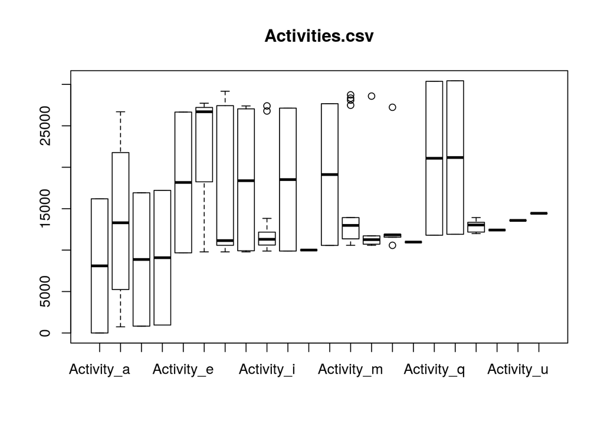

```r
boxplot( relative_gmt_ts ~ ActivityCodes, df.Act)
title("Activities.csv")
```

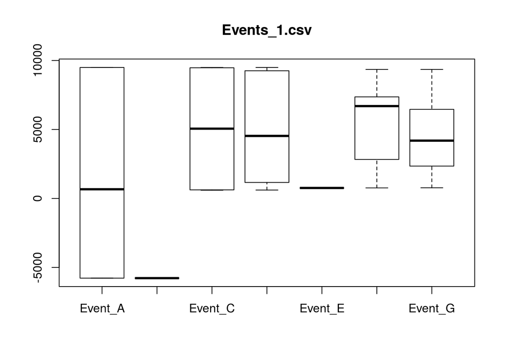

```r
boxplot( relative_gmt_ts ~ EventCodes, df.E1)
title("Events_1.csv")
```

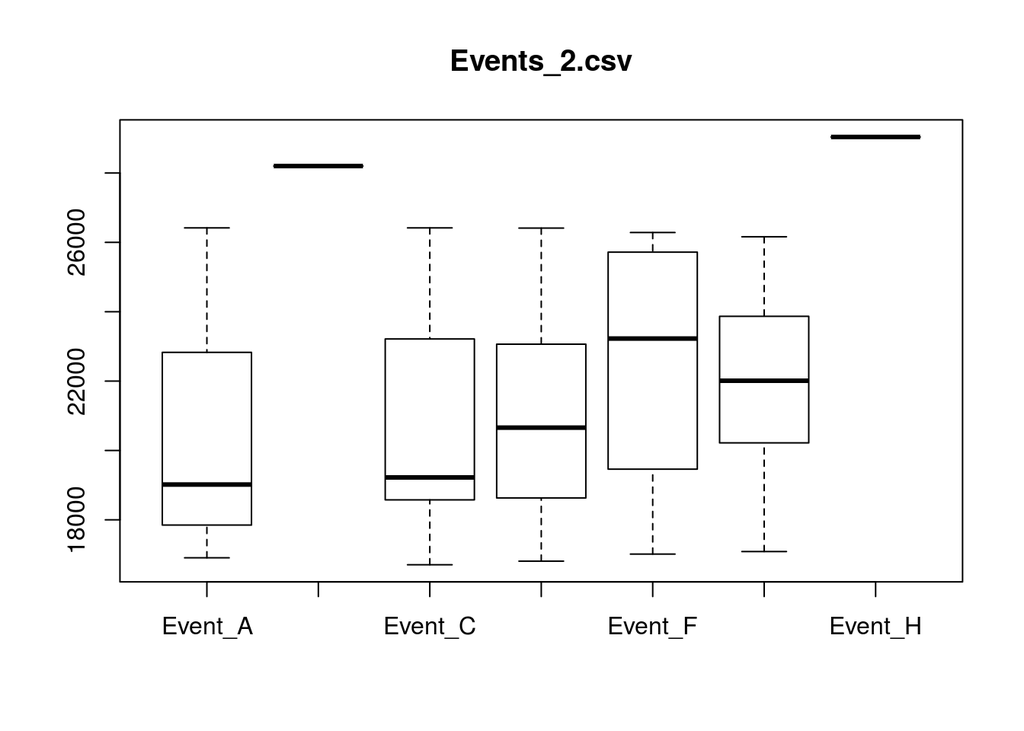

```r
boxplot( relative_gmt_ts ~ EventCodes, df.E2)
title("Events_2.csv")
```

3. Aggregate the tables based on activities or events

For each table, aggregate based on activities or events to get the *average*, *standard deviation*, and *length* of the relative gmt in seconds.

```r
meansd.act = aggregate(relative_gmt_ts~ActivityCodes, df.Act, FUN=function(x)c(ave=mean(x), std=sd(x), len=length(x)))
(meansd.act= meansd.act[order(meansd.act$relative_gmt_ts[, 1]), ])
```

```
##    ActivityCodes relative_gmt_ts.ave relative_gmt_ts.std
## 1     Activity_a           8096.5000          11450.1801
## 3     Activity_c           8871.5000          11380.8836
## 4     Activity_d           9082.5000          11491.1923
## 11    Activity_k          10009.0000                  NA
## 16    Activity_p          10968.0000                  NA
## 20    Activity_t          12423.0000                  NA
## 19    Activity_s          12880.7500            698.1023
## 9     Activity_i          13498.3571           5847.7737
## 2     Activity_b          13507.7500          10988.7581
## 21    Activity_u          13583.0000                  NA
## 14    Activity_n          14022.5000           7149.9873
## 22    Activity_v          14440.0000                  NA
## 15    Activity_o          14624.2000           7070.8298
## 13    Activity_m          15964.4118           7049.6122
```

[output cut: 31 more lines]

```r
meansd.e1 = aggregate(relative_gmt_ts~EventCodes, df.E1, FUN=function(x)c(ave=mean(x), std=sd(x), len=length(x)))
(meansd.e1 = meansd.e1[order(meansd.e1$relative_gmt_ts[, 1]), ])
```

```
##   EventCodes relative_gmt_ts.ave relative_gmt_ts.std relative_gmt_ts.len
## 2    Event_B           -5773.000               0.000              22.000
## 5    Event_E             761.000               0.000              15.000
## 1    Event_A            1463.667            6301.030              75.000
## 7    Event_G            4630.907            2516.708          143966.000
## 3    Event_C            5050.250            4439.407             136.000
## 4    Event_D            5200.483            3530.455             480.000
## 6    Event_F            5263.818            2792.366             880.000
```

```r
meansd.e2 = aggregate(relative_gmt_ts~EventCodes, df.E2, FUN=function(x)c(ave=mean(x), std=sd(x), len=length(x)))
(meansd.e2 = meansd.e2[order(meansd.e2$relative_gmt_ts[, 1]), ])
```

```
##   EventCodes relative_gmt_ts.ave relative_gmt_ts.std relative_gmt_ts.len
## 3    Event_C           20333.851            3148.527             478.000
## 1    Event_A           20339.250            3635.623             100.000
## 4    Event_D           21066.348            2751.033            1312.000
## 6    Event_G           21897.798            2386.421          117368.000
## 5    Event_F           22515.592            3081.929            3040.000
## 2    Event_B           28201.000               0.000              22.000
## 7    Event_H           29039.000               0.000              25.000
```

## Exploration summary

As shown in the boxplots and the aggregated table, we suspect

1. All events and activities happens on the same day, i.e. Tuesday, 5/10/2016;
2. Events1 and Events2 has the same format but are at different times;
3. Activities may be part of the events, thus they should have about the times;
4. The time difference between activities and corresponding events should be very small;

Based on the time-closeness, we may use KNN to classify the activities.

## Classification of Activities

### Data preprocessing

We need to integrate the events data sets together and keep the relevant columns which are “relative_gmt_ts”

```r
df.E = rbind(df.E1, df.E2)[ ,c('relative_gmt_ts', 'EventCodes')]
df.A = df.Act[, c('relative_gmt_ts','ActivityCodes')]
```

Events table:

```r
kable(head(df.E, 3), format = "markdown", align='l')
```

| relative_gmt_ts | EventCodes |
| --- | --- |
| -5773 | Event_A |
| -5773 | Event_A |
| -5773 | Event_A |

Activities table:

```r
kable(head(df.A, 3), format = "markdown", align='l')
```

| relative_gmt_ts | ActivityCodes |
| --- | --- |
| 0 | Activity_a |
| 739 | Activity_b |
| 824 | Activity_c |

### k-Nearest-Neighbor classification

We try 1, 5, 10, 15, 20-Nearest-Neighbor classification using the KNN classifier in library(class).

```r
# KNN prediction with k=1, 5, 10, 15, 20
df.A$Prediction_1NN = knn(as.matrix(df.E$relative_gmt_ts), as.matrix(df.A$relative_gmt_ts), df.E$EventCodes, k=1)
df.A$Prediction_5NN = knn(as.matrix(df.E$relative_gmt_ts), as.matrix(df.A$relative_gmt_ts), df.E$EventCodes, k=5)
df.A$Prediction_10NN = knn(as.matrix(df.E$relative_gmt_ts), as.matrix(df.A$relative_gmt_ts), df.E$EventCodes, k=10)
df.A$Prediction_15NN = knn(as.matrix(df.E$relative_gmt_ts), as.matrix(df.A$relative_gmt_ts), df.E$EventCodes, k=15)
df.A$Prediction_20NN = knn(as.matrix(df.E$relative_gmt_ts), as.matrix(df.A$relative_gmt_ts), df.E$EventCodes, k=20)
kable(df.A[order(df.A$ActivityCodes),-1], format="markdown", align = 'l')
```

|  | ActivityCodes | Prediction_1NN | Prediction_5NN | Prediction_10NN | Prediction_15NN | Prediction_20NN |
| --- | --- | --- | --- | --- | --- | --- |
| 1 | Activity_a | Event_C | Event_C | Event_C | Event_C | Event_C |
| 70 | Activity_a | Event_C | Event_C | Event_C | Event_C | Event_C |
| 2 | Activity_b | Event_E | Event_E | Event_E | Event_E | Event_F |
| 6 | Activity_b | Event_A | Event_A | Event_A | Event_A | Event_A |
| 71 | Activity_b | Event_D | Event_D | Event_D | Event_D | Event_D |
| 75 | Activity_b | Event_A | Event_A | Event_A | Event_A | Event_A |
| 3 | Activity_c | Event_G | Event_G | Event_G | Event_G | Event_G |
| 72 | Activity_c | Event_D | Event_D | Event_D | Event_D | Event_A |
| 4 | Activity_d | Event_G | Event_G | Event_G | Event_G | Event_G |
| 73 | Activity_d | Event_G | Event_G | Event_G | Event_G | Event_G |
| 5 | Activity_e | Event_A | Event_A | Event_A | Event_A | Event_A |
| 74 | Activity_e | Event_A | Event_A | Event_A | Event_A | Event_A |
| 7 | Activity_f | Event_A | Event_A | Event_A | Event_A | Event_A |
| 76 | Activity_f | Event_A | Event_A | Event_A | Event_A | Event_A |
| 90 | Activity_f | Event_B | Event_B | Event_B | Event_B | Event_B |
| 8 | Activity_g | Event_A | Event_A | Event_A | Event_A | Event_A |
| 15 | Activity_g | Event_A | Event_A | Event_A | Event_A | Event_A |
| 16 | Activity_g | Event_A | Event_A | Event_A | Event_A | Event_A |
| 18 | Activity_g | Event_A | Event_A | Event_A | Event_A | Event_A |
| 25 | Activity_g | Event_A | Event_A | Event_A | Event_A | Event_A |
| 27 | Activity_g | Event_A | Event_A | Event_A | Event_A | Event_A |
| 30 | Activity_g | Event_A | Event_A | Event_A | Event_A | Event_A |
| 34 | Activity_g | Event_A | Event_A | Event_A | Event_A | Event_A |
| 35 | Activity_g | Event_A | Event_A | Event_A | Event_A | Event_A |
| 80 | Activity_g | Event_A | Event_A | Event_A | Event_A | Event_A |
| 81 | Activity_g | Event_A | Event_A | Event_A | Event_A | Event_A |
| 83 | Activity_g | Event_A | Event_A | Event_A | Event_A | Event_A |
| 87 | Activity_g | Event_B | Event_B | Event_B | Event_B | Event_B |
| 89 | Activity_g | Event_B | Event_B | Event_B | Event_B | Event_B |
| 94 | Activity_g | Event_B | Event_B | Event_B | Event_B | Event_B |

[output cut: 68 more lines]

From the results, we can see the prediction are very consistent among different k’s, which make us feel confident with our prediction. To use a moderate model complexity, we pick 5-NN predictions as the final prediction. The final prediction is a majority vote of all predictions. In most cases, there is only 1 choice.

```r
# find the majority of prediction for a certain activity
activities = sort(unique(df.A$ActivityCodes))
prediction = rep('', length(activities))
for(i in 1:length(activities)){
  pred = df.A$Prediction_5NN[ df.A$ActivityCodes==activities[i] ]
  pred = as.character(names(which.max(table(pred))))
  prediction[i] = pred
}
df.Final_Prediction = data.frame(Activites=activities, Match_Prediction=prediction)
kable(df.Final_Prediction, format = "markdown", align = 'l')
```

| Activites | Match_Prediction |
| --- | --- |
| Activity_a | Event_C |
| Activity_b | Event_A |
| Activity_c | Event_D |
| Activity_d | Event_G |
| Activity_e | Event_A |
| Activity_f | Event_A |
| Activity_g | Event_A |
| Activity_h | Event_A |
| Activity_i | Event_A |
| Activity_j | Event_A |
| Activity_k | Event_A |
| Activity_l | Event_A |
| Activity_m | Event_A |
| Activity_n | Event_A |
| Activity_o | Event_A |
| Activity_p | Event_A |
| Activity_q | Event_A |
| Activity_r | Event_A |
| Activity_s | Event_A |
| Activity_t | Event_A |
| Activity_u | Event_C |
| Activity_v | Event_C |

## Conclusion

The data sets consist of information of activities and events. By data exploration, the activities are suspected to be in certain events at about the same time. Based on the nature of the problem, we choose KNN classfier to match the activities to the corresponding events. From the results with different KNN classifiers, we are confident to make the prediction as shown in the table above.

**Note**

1. This report is to shown the whole process, from knowing nothing to predictive modeling; in real-work environment, most outputs and tables will be removed to keep the story straightforward and easy to understand.
2. I should have allowed more time to ask questions and to learn more about the data, but I will be travaling to Mountain View tomorrow for an onsite interview. I hope we could talk on Monday afternoon if I have the opportunity.
3. If I have more time, I would write more documentation and use more R functions to keep it concise.
4. I am proficient in Python and C++, too. That’s also why my R code sometimes looks like C++ or Python style.